# param deep dive

Arnie Seong

04 February 2026

```r
# load ----
img_suffixes <- c(paste0("_e", 1:9, "e_+05.png"), "_e1e_+06.png")

stem_pvtau1 <- here::here("sims", "results", "hshoe_smooth_pvtau_1721632_12500obs_")
stem_pvtau2 <- here::here("sims", "results", "hshoe_smooth_pvtau_2721632_12500obs_")
seed_pvtau2 <- c(19709, 809872, 264744, 498729, 336130, 263808, 877164, 218489, 234821, 616240)
seed_pvtau1 <- c(561114, 453639, 663173, 108703, 165780)

resfile_pvtau1 <- paste0(stem_pvtau1, seed_pvtau1, ".RData")
modfile_pvtau1 <- paste0(stem_pvtau1, seed_pvtau1, ".pt")

resfile_pvtau2 <- paste0(stem_pvtau2, seed_pvtau2, ".RData")
modfile_pvtau2 <- paste0(stem_pvtau2, seed_pvtau2, ".pt")

res_fnames <- c(resfile_pvtau1, resfile_pvtau2)
mod_fnames <- c(modfile_pvtau1, modfile_pvtau2)
seeds <- c(seed_pvtau1, seed_pvtau2)
```

# 10k obs

```r
# check model fits across sims
load(res_fnames[1])
epoch <- 1:nrow(sim_res$loss_mat) * sim_res$sim_params$report_every
lmat <- cbind(1, epoch, sim_res$loss_mat)
colnames(lmat)[1] <- "sim"

for (sim_ind in 2:length(seeds)){
  load(res_fnames[sim_ind])
  epoch <- 1:length(sim_res$loss_mat) * sim_res$sim_params$report_every
  curr_lmat <- cbind(sim_ind, epoch, sim_res$loss_mat)
  lmat <- rbind(lmat, curr_lmat)
}

colnames(lmat)
```

```
## [1] "sim"       "epoch"     "kl"        "mse_train" "mse_test"
```

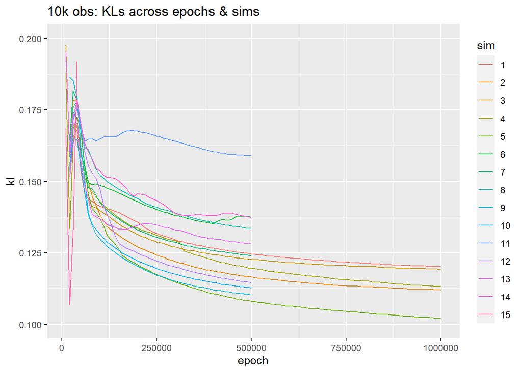

```r
lmat %>%
  as_data_frame() %>%
  mutate(sim = factor(sim)) %>%
  ggplot(aes(y = kl, x = epoch, color = sim)) +
  geom_line() +
  ylim(c(0.1, 0.2)) +
  labs(title = "10k obs: KLs across epochs & sims")
```

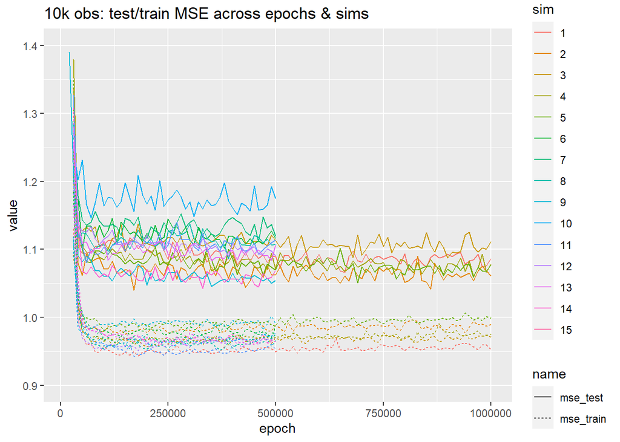

```r
lmat %>%
  as_data_frame() %>%
  mutate(sim = factor(sim)) %>%
  pivot_longer(cols = -c("epoch", "sim")) %>%
  filter(name != "kl") %>%
  ggplot(aes(x = epoch, color = sim, linetype = name)) +
  geom_line(aes(y = value)) +
  ylim(c(0.9, 1.4)) +
  labs(title = "10k obs: test/train MSE across epochs & sims")
```

**Note:** sims 1-5 trained for 1M epochs; 6-15 for 500k epochs.

- KL divergences continually decrease;
- neigther train (dotted) nor test MSE seem to benefit significantly from longer training;
  - however, slight upward trend in train MSE towards 1 (true value of $\sigma^2_\epsilon$) indicates further training actually alleviates overfitting somewhat.

## weight params

- looking at sim 11 (known good; can compare to known bad 15)

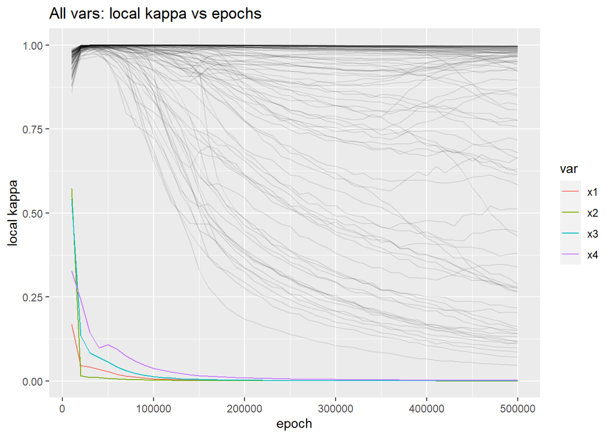

```r
sim_ind <- 11
load(res_fnames[sim_ind])
nn_mod <- torch_load(mod_fnames[sim_ind])

varmat_pltfcn(
  sim_res$kappa_local_mat,
  y_name = "local kappa",
  burn = 0
)$all_vars_plt
```

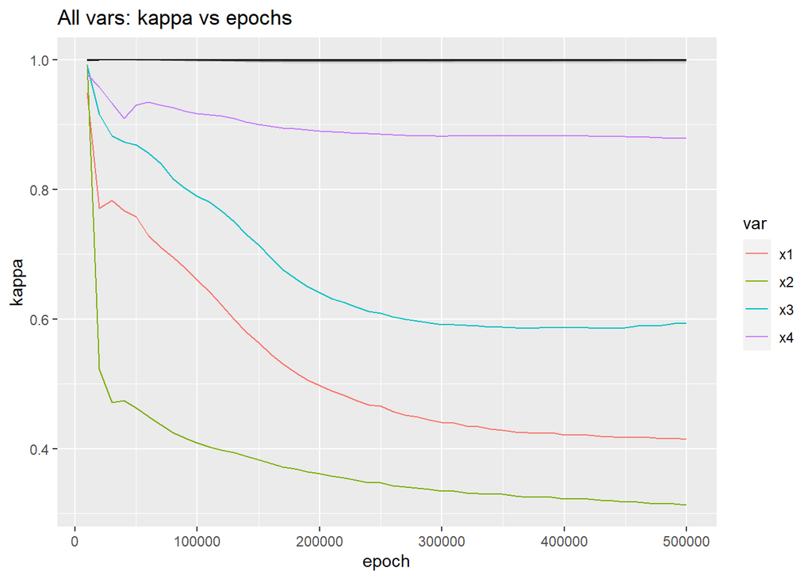

```r
varmat_pltfcn(
  sim_res$kappa_mat,
  y_name = "kappa",
  burn = 0
)$all_vars_plt
```

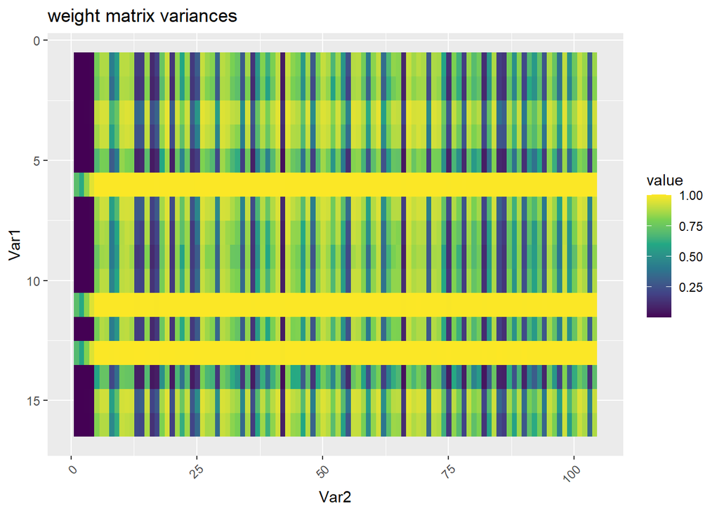

```r
k1 <- get_kappas(nn_mod$fc1)
k2 <- get_kappas(nn_mod$fc2)
wtil_params <- get_wtil_params(nn_mod$fc1)
w_mu <- wtil_params$wtil_mu
w_lvar <- wtil_params$wtil_lvar
w_var <- exp(w_lvar)

vismat(exp(w_lvar)) +
  labs(title = "weight matrix variances")
```

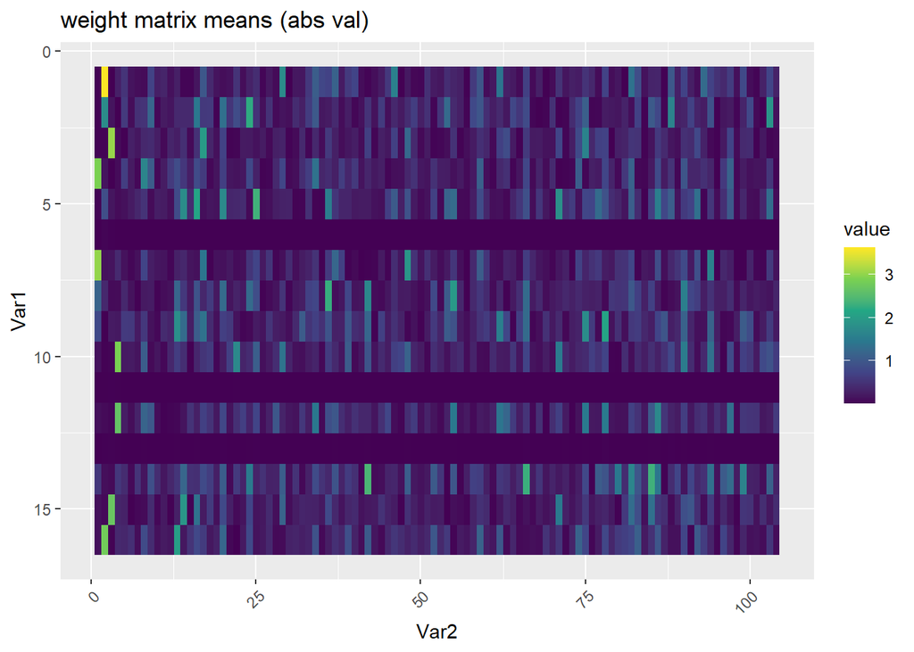

```r
vismat(abs(w_mu)) +
  labs(title = "weight matrix means (abs val)")
```

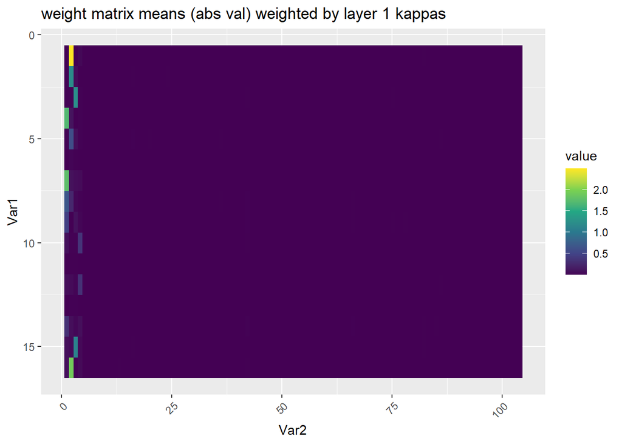

```r
k1_weighted_mu <- sweep(abs(w_mu), MARGIN = 2, STATS = (1 - k1), FUN = "*")
k12_weighted_mu <- sweep(abs(k1_weighted_mu), MARGIN = 1, STATS = (1 - k2), FUN = "*")
vismat(k1_weighted_mu) +
  labs(title = "weight matrix means (abs val) weighted by layer 1 kappas")
```

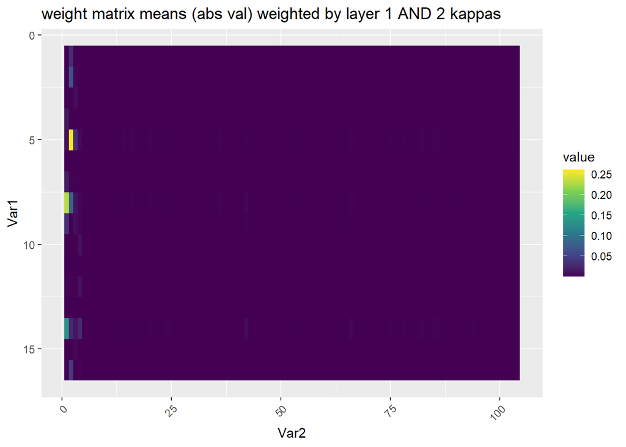

```r
vismat(k12_weighted_mu) +
  labs(title = "weight matrix means (abs val) weighted by layer 1 AND 2 kappas")
```

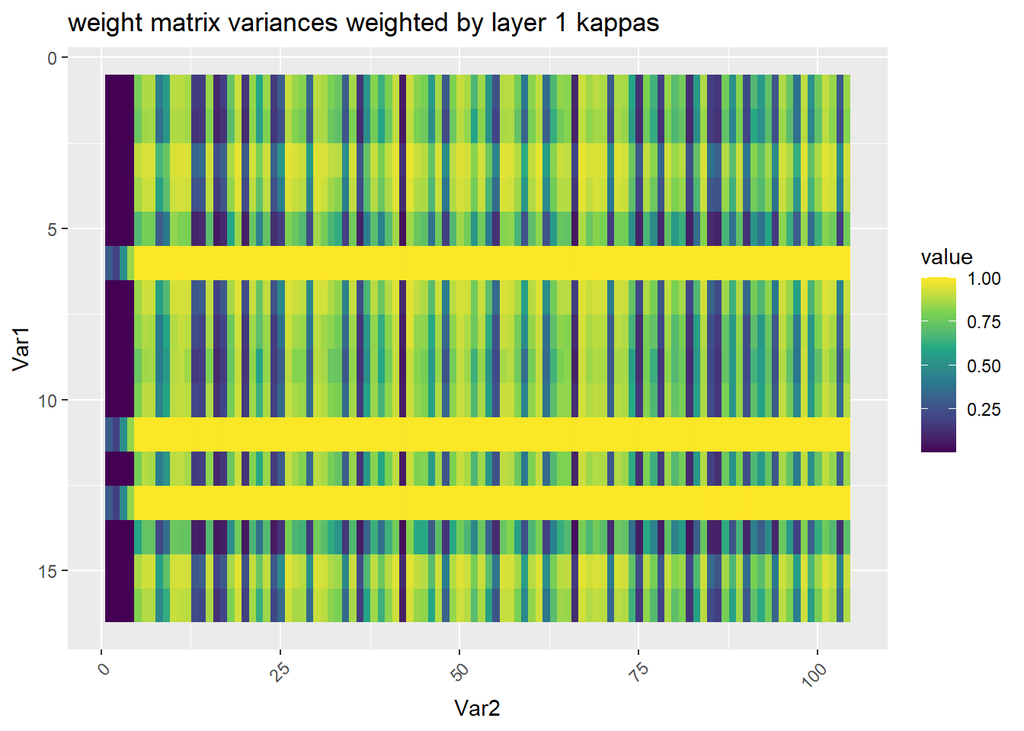

```r
k1_weighted_var <- sweep(w_var, MARGIN = 2, STATS = k1, FUN = "*")
k2_weighted_var <- sweep(w_var, MARGIN = 1, STATS = k2, FUN = "*")
k12_weighted_var <- sweep(k1_weighted_var, MARGIN = 1, STATS = k2, FUN = "*")
vismat(k1_weighted_var) +
  labs(title = "weight matrix variances weighted by layer 1 kappas")
```

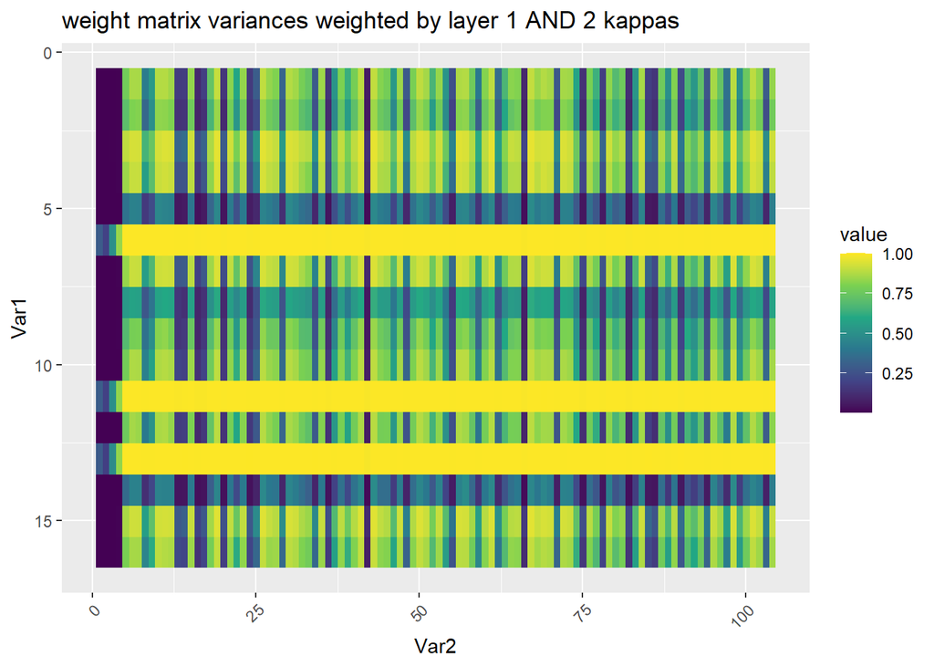

```r
vismat(k12_weighted_var) +
  labs(title = "weight matrix variances weighted by layer 1 AND 2 kappas")
```

### inspecting $\sigma_{\tilde{w}}$ across training epochs

layer 2 kappas (neuron dropout):

```r
k2 <- get_kappas(nn_mod$fc2)
k2
```

```
##  [1] 0.9881876 0.9458429 0.9952292 0.9919315 0.5549875 0.9999999 0.9904498
##  [8] 0.6587199 0.9256688 0.9760094 0.9999999 0.9738676 0.9999999 0.5945113
## [15] 0.9966778 0.9783996
```

```r
for (i in 1:length(k2)){

  cat("\n  \n  \n#### ", i, "th neuron \n")

  plt_title <- paste0("var(tilde_w) ~ epochs; k2=", round(k2[i], 4))
  print(
    varmat_pltfcn(
      exp(sim_res$w_lvar_arr[i,,]),
      y_name = "var(tilde_w)",
      burn = 0
    )$all_vars_plt +
      labs(title = plt_title)
  )
}
```

#### 1 th neuron

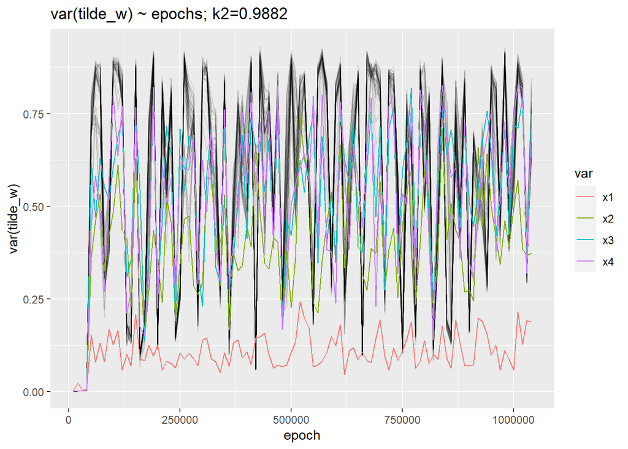

#### 2 th neuron

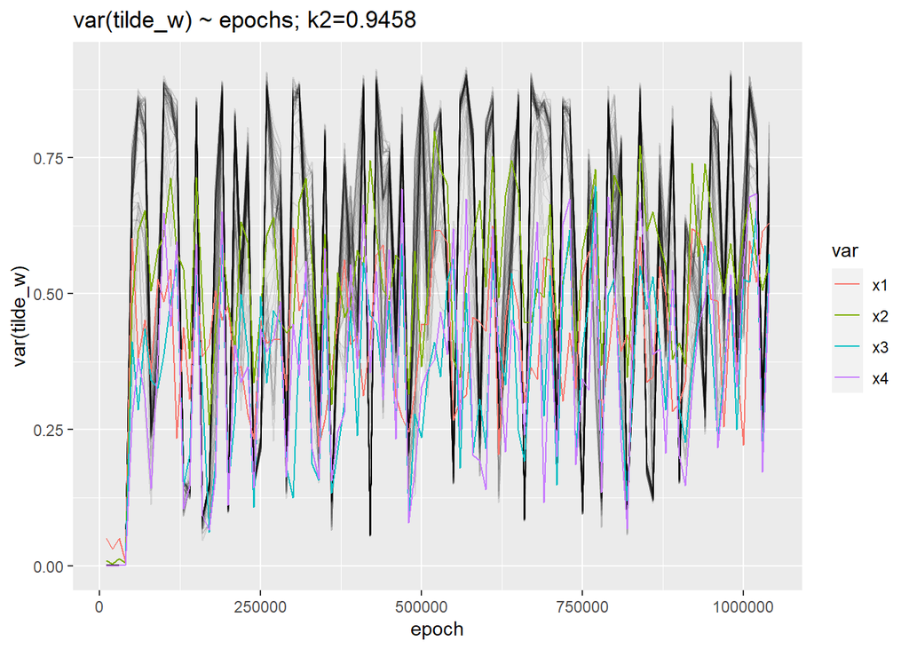

#### 3 th neuron

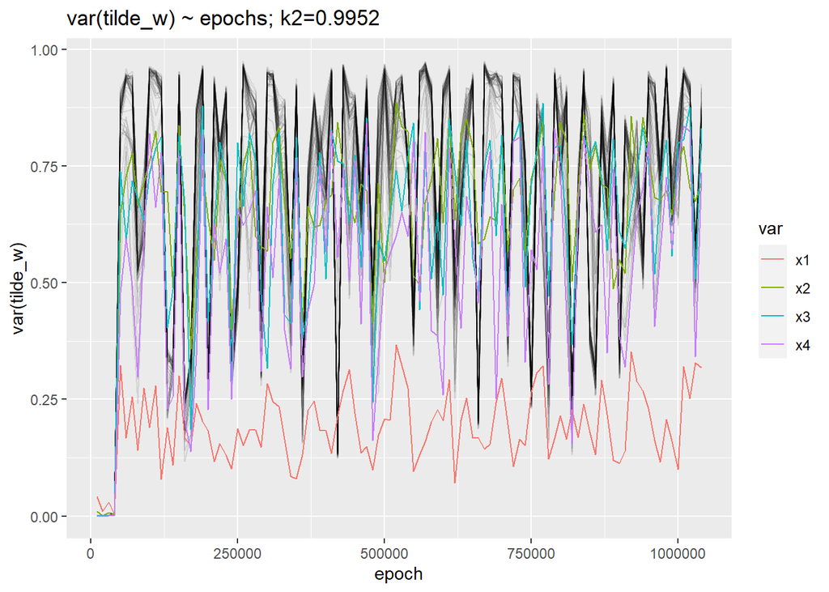

#### 4 th neuron

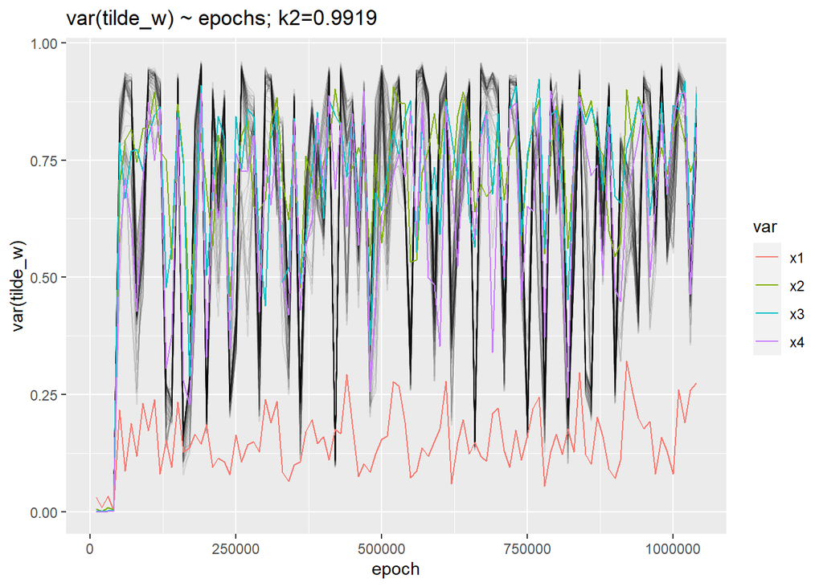

#### 5 th neuron

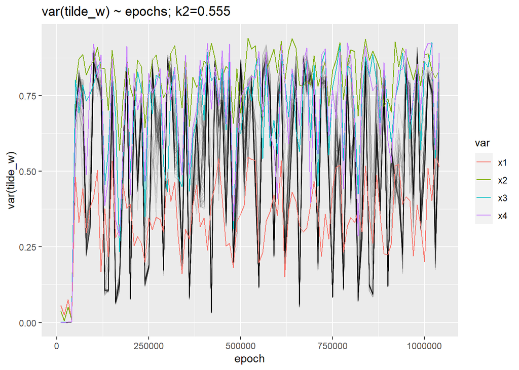

#### 6 th neuron

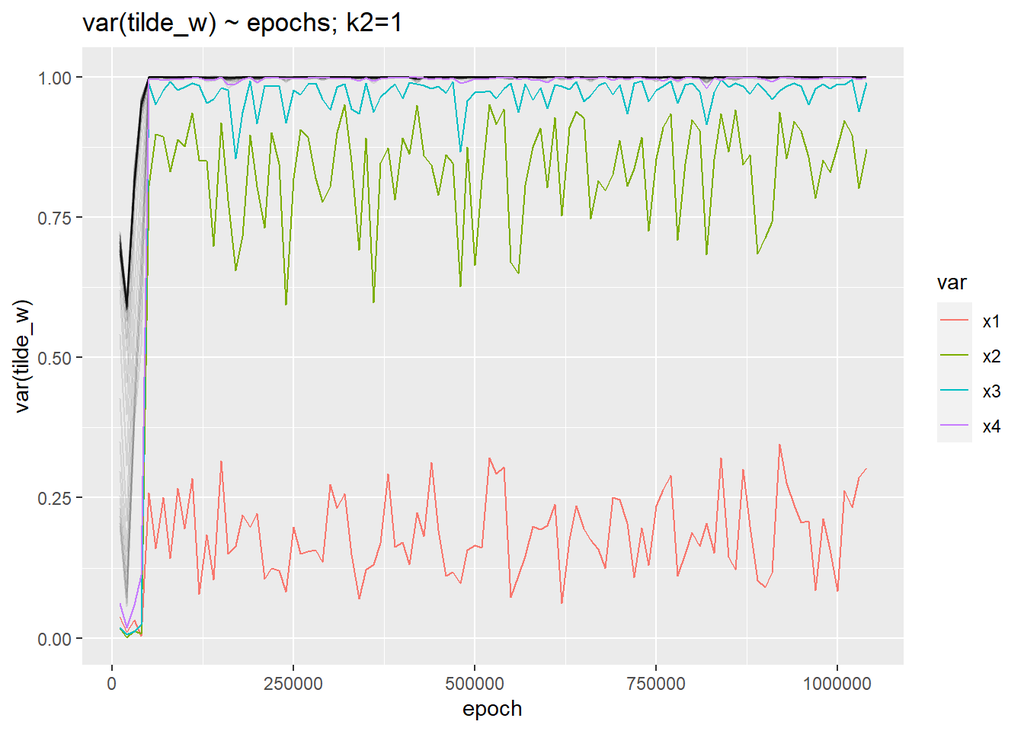

#### 7 th neuron

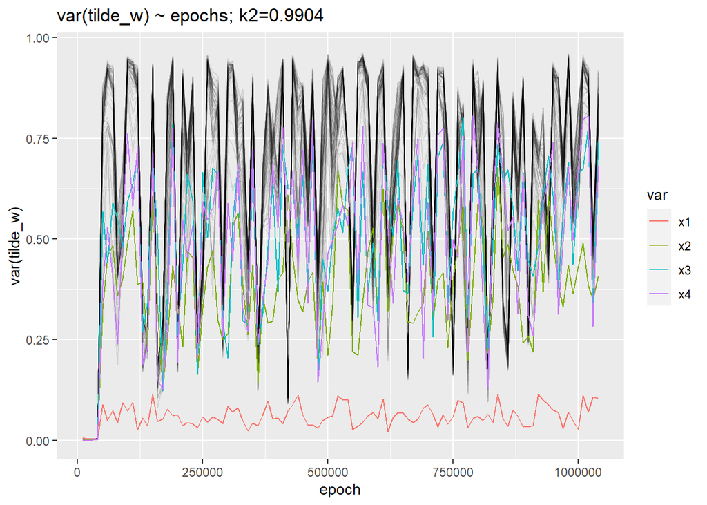

#### 8 th neuron

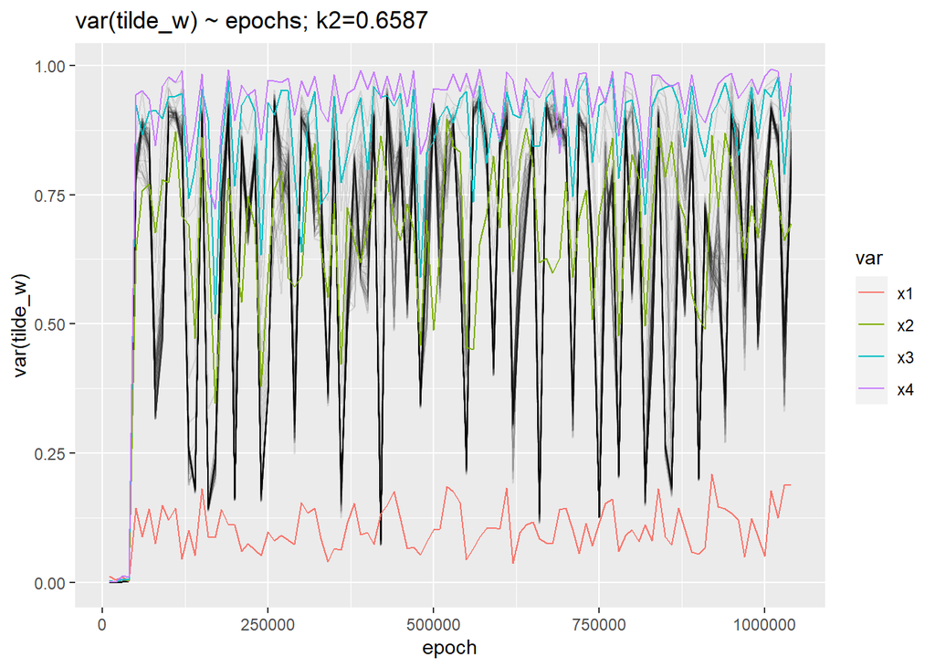

#### 9 th neuron

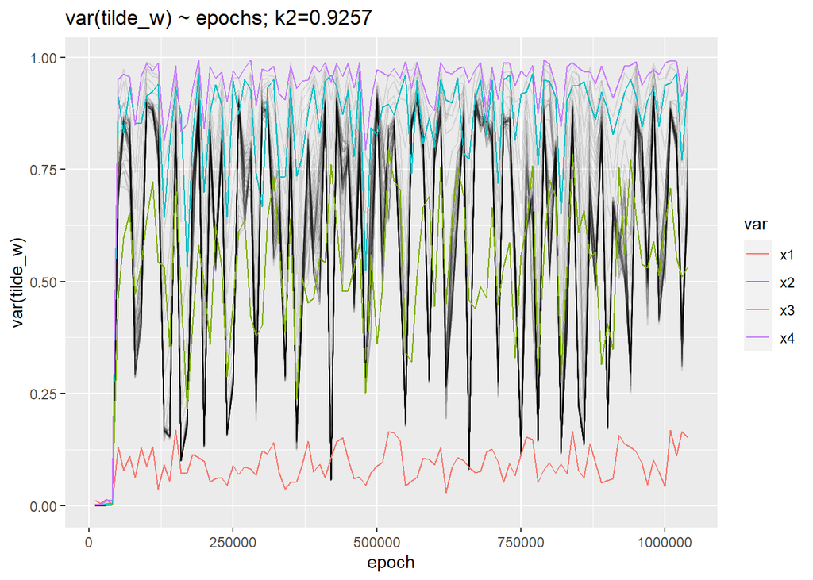

#### 10 th neuron

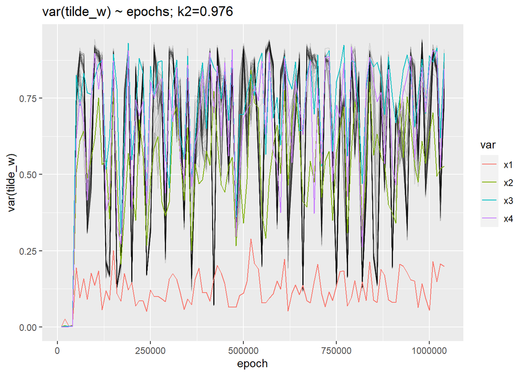

#### 11 th neuron

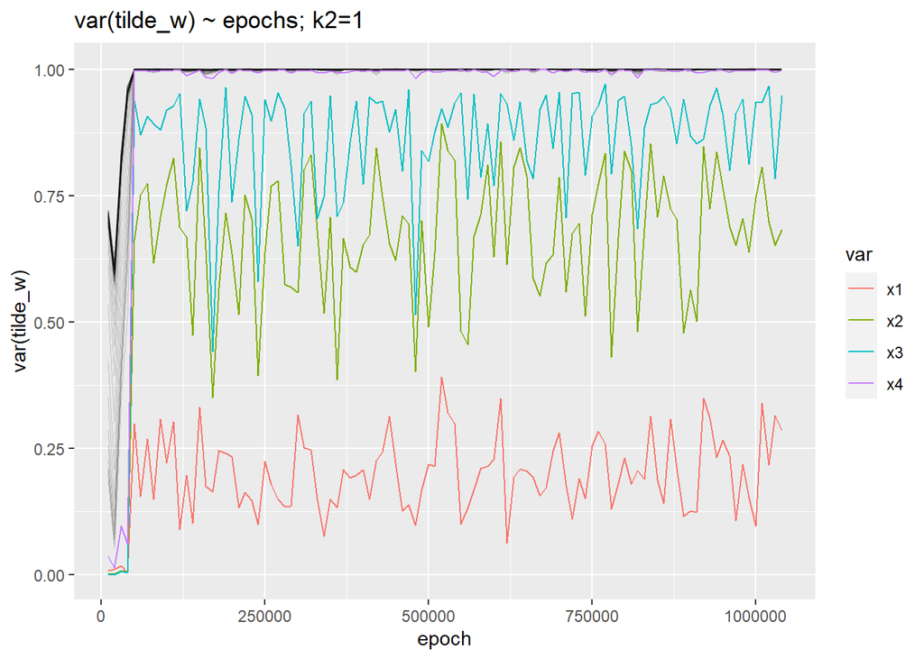

#### 12 th neuron

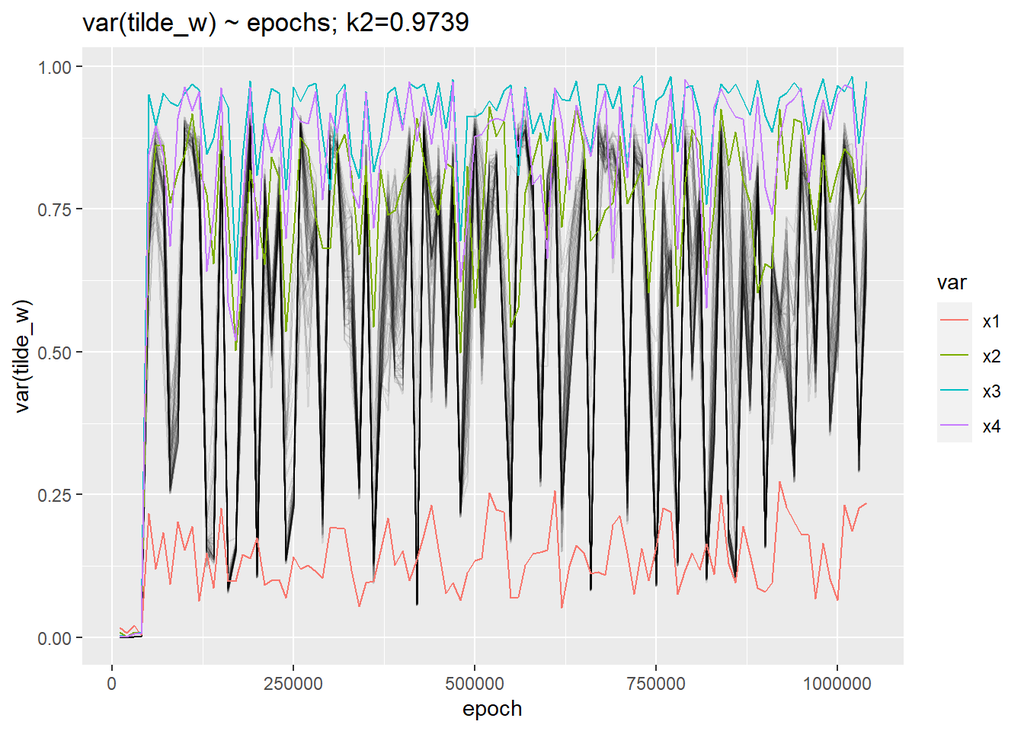

#### 13 th neuron

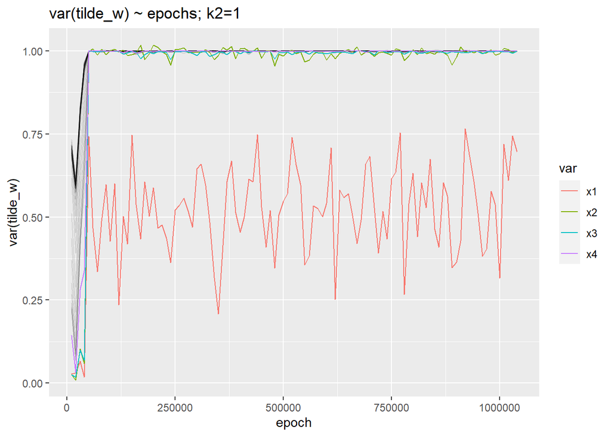

#### 14 th neuron

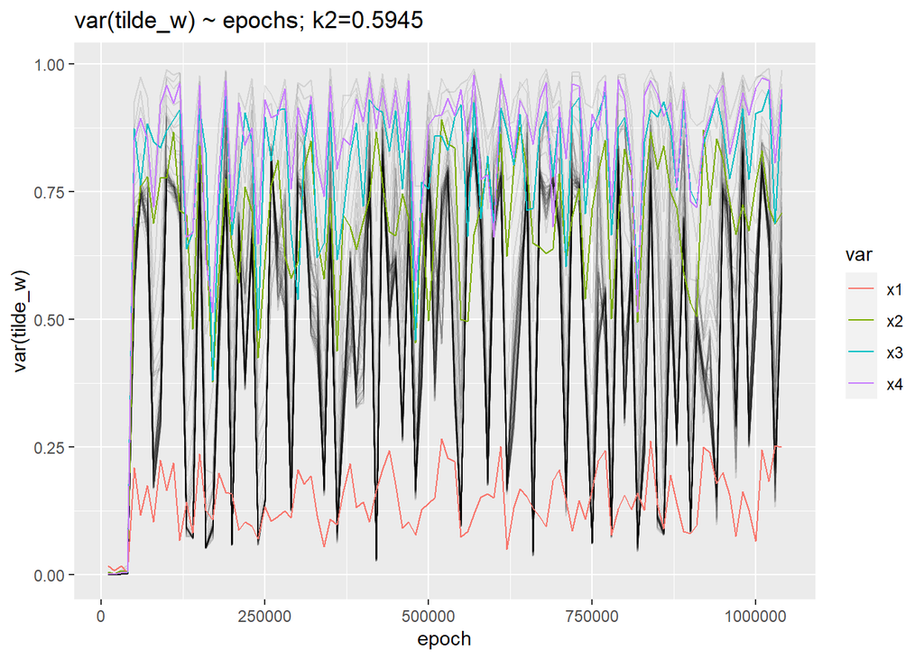

#### 15 th neuron

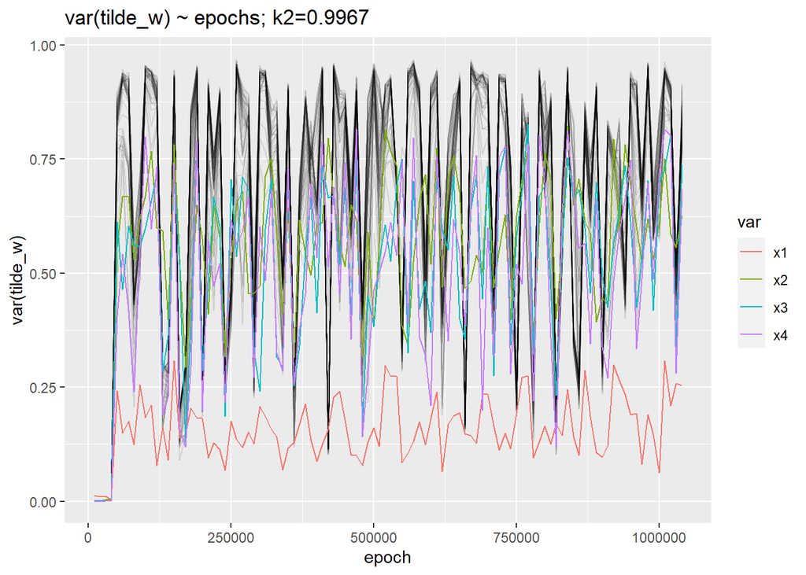

#### 16 th neuron

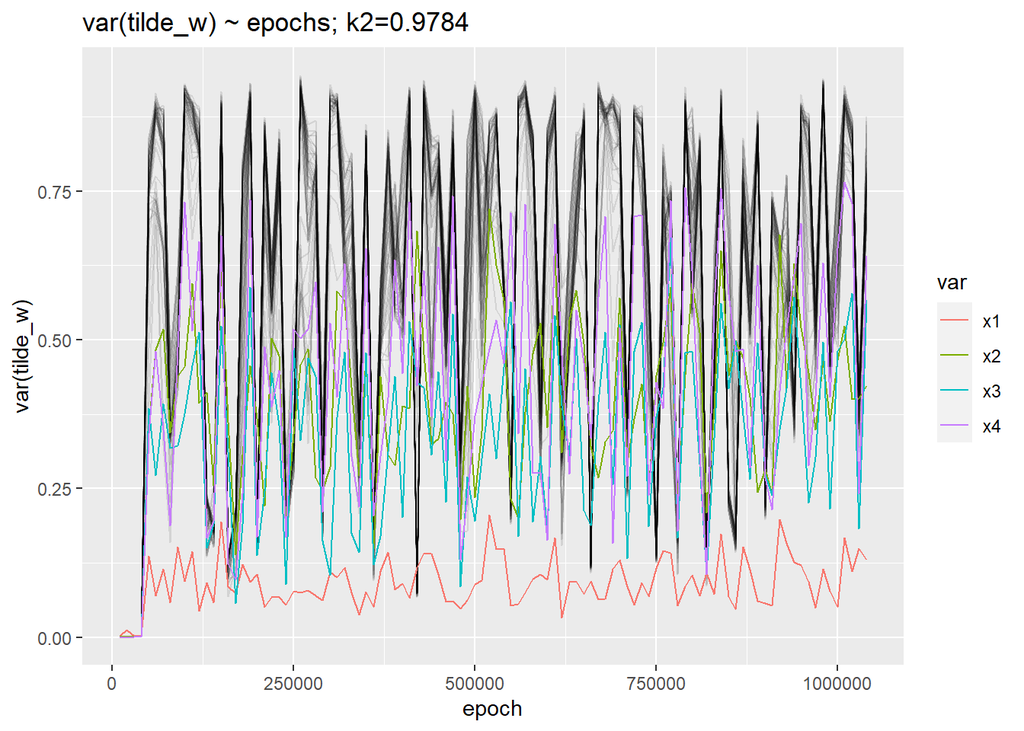

# Corrections

$\tau$ correction,

iterative $\tau$ correction:

- rationale: tracks (to some degree at least) the impact of the scale parameters through all network layers.
- possible issues:
  - Frobenius norm of a matrix in general grows with dimension. This is, however, likely mitigated by the horseshoe scale parameters in each layer.
  - Not sure about theory. Just working off the idea that the Frobenius norm measures in some sense the “magnitude” of a matrix. Intuition is that the intervening layers all contribute to shrinkage.

```r
# $k_1_corr = 1 - (1-k1) * ||diag(1-k2) W_2|| * ||diag(z3) W_3||$
# or, alternatively $z1_corr = Z1 * ||diag(Z2) W2|| * ||diag(Z3) W_3||$
frob <- function(mat){
  sqrt(sum(mat^2))
}

k1 <- get_kappas(nn_mod$fc1)
k2 <- get_kappas(nn_mod$fc2)
k3 <- get_kappas(nn_mod$fc3)
w2 <- get_wtil_params(nn_mod$fc2)$wtil_mu
w3 <- get_wtil_params(nn_mod$fc3)$wtil_mu

# doesn't work on kappa parameters (negative values)
# k1_c <- 1 - (1 - k1) * frob(diag(1-k2) %*% t(w2)) * frob(diag(1-k3)%*%t(w3))
# cbind(k1, k1_c)[1:10, ]

z1 <- sqrt(get_zsq(nn_mod$fc1))
z2 <- sqrt(get_zsq(nn_mod$fc2))
z3 <- sqrt(get_zsq(nn_mod$fc3))

z1_frob <- z1 * frob(diag(z2) %*% t(w2)) * frob(diag(z3) %*% t(w3))
k1_frob <- (1 + z1_frob^2)^(-1)
```

## iteratively-corrected kappas

- kappas generated by applying tau correction throughout network

```r
# using layer 2 only
m2 <- m_eff(nn_mod$fc2)
k1_taucorr <- (1 + z1^2 * 16/m2)^(-1)

# iteratively over layers
get_kappas_taucorrected_iterative <- function(nn_mod){
  L <- length(nn_mod$children)
  m_eff_l <- sum(1 - get_kappas(nn_mod$children[[L]]))

  for (l in L:2){
    correction_l <- length(get_kappas(nn_mod$children[[l]])) / m_eff_l
    zsq_l <- get_zsq(nn_mod$children[[l-1]])
    k_l_corrected <- (1 + zsq_l*correction_l)^(-1)
    m_eff_l <- sum(1-k_l_corrected)
  }

  return(k_l_corrected)
}

# apply(w_mu^2 / w_var, 2, mean)
# W_var <- sweep(w_var, 2, zsq1, "*")
# wvar_weighted_zsq1 <- apply(W_var, 2, mean)
#
#
#
# w_var <- exp(w_lvar)
# dim(w_var)
#
# tm <- matrix(rep(1:5, 3), nrow = 5)
# tm
# sweep(tm, MARGIN = 2, STATS = 1:3, FUN = "*")
```

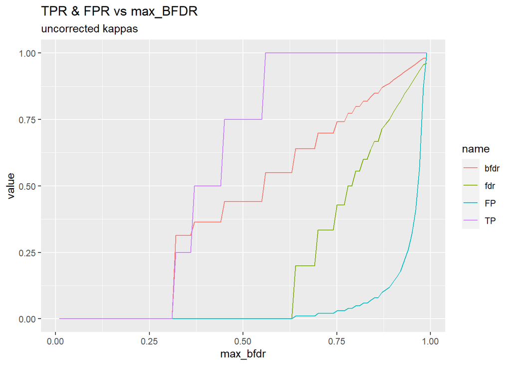

```r
err_by_max_bfdr(k1)$plt_fdrs +
  labs(subtitle = "uncorrected kappas")
```

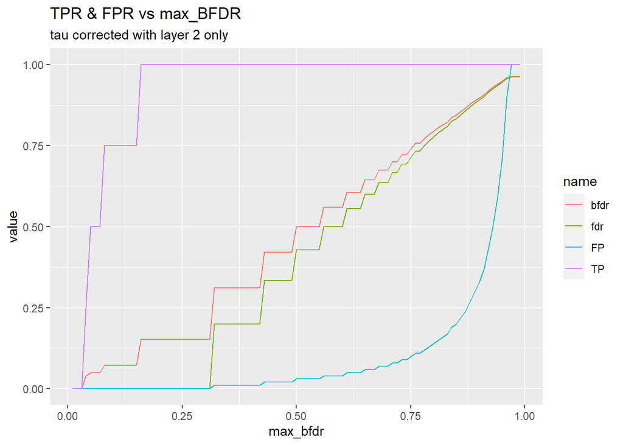

```r
err_by_max_bfdr(get_kappas_taucorrected(nn_mod))$plt_fdrs +
  labs(subtitle = "tau corrected with layer 2 only")
```

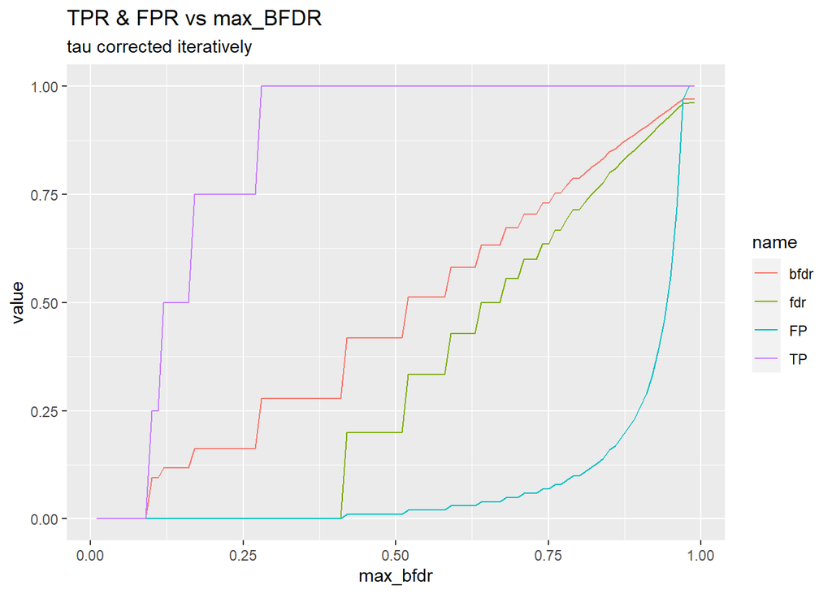

```r
err_by_max_bfdr(get_kappas_taucorrected_iterative(nn_mod))$plt_fdrs +
  labs(subtitle = "tau corrected iteratively")
```

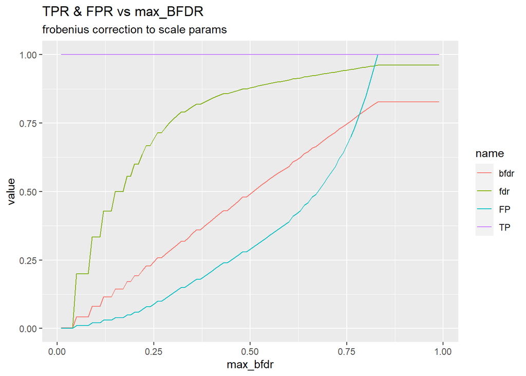

```r
err_by_max_bfdr(k1_frob)$plt_fdrs +
  labs(subtitle = "frobenius correction to scale params")
```

```r
# checking functions places in `analysis_fcns.R`
# err_by_max_bfdr(get_kappas_frobcorrected(nn_mod))$plt_fdrs
# err_by_max_bfdr(get_kappas_taucorrected(nn_mod, ln_mean))$plt_fdrs

cbind(k1, k1_taucorr, k1_frob)[1:20,]
```

```
##              k1 k1_taucorr      k1_frob
##  [1,] 0.4147584 0.05954787 0.0007982035
##  [2,] 0.3136256 0.03922315 0.0005147866
##  [3,] 0.5941302 0.11566009 0.0016473248
##  [4,] 0.8786113 0.39271671 0.0080926378
##  [5,] 0.9999890 0.99987640 0.9902971997
##  [6,] 0.9999979 0.99997700 0.9981805680
##  [7,] 0.9999977 0.99997377 0.9979251275
##  [8,] 0.9997833 0.99758015 0.8387367654
##  [9,] 0.9999112 0.99900677 0.9269520411
## [10,] 0.9999989 0.99998720 0.9989866150
## [11,] 0.9999986 0.99998406 0.9987379902
## [12,] 0.9999973 0.99997026 0.9976479614
## [13,] 0.9986158 0.98472231 0.4484829038
## [14,] 0.9987180 0.98583659 0.4675608751
## [15,] 0.9999957 0.99995224 0.9962282717
## [16,] 0.9975864 0.97363454 0.3178246469
## [17,] 0.9987434 0.98611377 0.4725540632
## [18,] 0.9999838 0.99981836 0.9858045519
## [19,] 0.9999991 0.99999035 0.9992353423
## [20,] 0.9983292 0.98161250 0.4024558811
```

```r
# zsq1 <- get_zsq(nn_mod$fc1)
# zsq2 <- get_zsq(nn_mod$fc2)
#
# zmat <- t(outer(sqrt(zsq1), sqrt(zsq2)))
# apply(zmat, 2, geom_mean)
#
#
#
# # older thoughts
# # Wald_mat <- w_mu^2 / w_var
# # tstat <- sqrt(Wald_mat)
# # colMeans(Wald_mat)
# # colMeans(tstat)
# #
# # apply(Wald_mat, 2, geom_mean)
# # apply(tstat, 2, geom_mean)
# #
# # apply(k12_weighted_var, 2, geom_mean)
#
#
#
# zsq1 <- get_zsq(nn_mod$fc1)
# zsq2 <- get_zsq(nn_mod$fc2)
# z2wvar <- sweep(w_var, MARGIN = 1, STATS = sqrt(zsq2), FUN = "*")
# vismat(z2wvar)
#
#
# apply(w_var, 2, geom_mean)
#
# w_var_z2weighted <- geom_mean(sqrt(zsq2)) / apply(z2wvar, 2, geom_mean)
#
# varmat_pltfcn(
#   sim_res$alpha_mat,
#   y_name = "alpha",
#   burn = 0
# )$all_vars_plt
#
#
# varmat_pltfcn(
#   sim_res$kappa_local_mat,
#   y_name = "local kappa",
#   burn = 0
# )$all_vars_plt
#
# varmat_pltfcn(
#   sim_res$kappa_mat,
#   y_name = "kappa",
#   burn = 0
# )$all_vars_plt
#
# k1 <- get_kappas(nn_mod$fc1)
# k2 <- get_kappas(nn_mod$fc2)
# wtil_params <- get_wtil_params(nn_mod$fc1)
# w_mu <- wtil_params$wtil_mu
# w_lvar <- wtil_params$wtil_lvar
#
# vismat(exp(w_lvar))
# vismat(w_mu)
#
#
#
#
#
#
#
# get_kappas(nn_mod$fc2)
# # 3, 4, 8, 10
# varmat_pltfcn(
#   exp(sim_res$w_lvar_arr[2,,]),
#   y_name = "var(tilde_w)",
#   burn = 0
# )$all_vars_plt
#
#
# varmat_pltfcn(
#   exp(sim_res$w_lvar_arr[3,,]),
#   y_name = "var(tilde_w)",
#   burn = 0
# )$all_vars_plt
#
# varmat_pltfcn(
#   exp(sim_res$w_lvar_arr[10,,]),
#   y_name = "var(tilde_w)",
#   burn = 0
# )$all_vars_plt






# sim_ind <- 1
#
# ztilsq_1 <- get_ztil_sq(nn_mod$fc1)
# ssq_1 <- get_s_sq(nn_mod$fc1)
# ztilsq_2 <- get_ztil_sq(nn_mod$fc2)
# ssq_2 <- get_s_sq(nn_mod$fc2)
#
# zsq_1 <- ztilsq_1 * ssq_1
# zsq_2 <- ztilsq_2 * ssq_2
#
# zsq_1_tc <- zsq_1 * (16 / m_eff(nn_mod$fc2))^2
# k_1_tc <- (1 + zsq_1_tc)^(-1)
# err_mat <- err_by_max_bfdr(k_1_tc)$err_mat
# err_mat[, 1:5] %>%
#   as_data_frame() %>%
#   pivot_longer(cols = -max_bfdr) %>%
#   ggplot(aes(y = value, x = max_bfdr, color = name)) +
#   geom_line() +
#   labs(
#     title = paste0("tau_corr 1: sim ", sim_ind, ": FP/TP vs max_BFDR")
#   )
#
#
# zsq_1_tc2 <- zsq_1 * (16 / m_eff(nn_mod$fc2))
# k_1_tc2 <- (1 + zsq_1_tc2)^(-1)
# err_mat2 <- err_by_max_bfdr(k_1_tc2)$err_mat
# err_mat2[, 1:5] %>%
#   as_data_frame() %>%
#   pivot_longer(cols = -max_bfdr) %>%
#   ggplot(aes(y = value, x = max_bfdr, color = name)) +
#   geom_line() +
#   labs(
#     title = paste0("tau_corr 2 (sqrt): sim ", sim_ind, ": FP/TP vs max_BFDR")
#   )
#
```

```r
# load ----
seeds <- c(
  215244,
  272835,
  124107,
  782699,
  798186,
  68021,
  849913,
  283608,
  658409,
  130356
)

mod_stem <- here::here("sims", "results", "hshoe_smooth_pvtau_testfewer21632_1250obs_")
mod_fnames <- paste0(mod_stem, seeds, ".pt")
res_fnames <- paste0(mod_stem, seeds, ".RData")
```

# $X$ norm, 1k obs

```r
# check model fits across sims
load(res_fnames[1])
epoch <- 1:nrow(sim_res$loss_mat) * sim_res$sim_params$report_every
lmat <- cbind(1, epoch, sim_res$loss_mat)
colnames(lmat)[1] <- "sim"

for (sim_ind in 2:length(seeds)){
  load(res_fnames[sim_ind])
  epoch <- 1:length(sim_res$loss_mat) * sim_res$sim_params$report_every
  curr_lmat <- cbind(sim_ind, epoch, sim_res$loss_mat)
  lmat <- rbind(lmat, curr_lmat)
}

colnames(lmat)
```

```
## [1] "sim"       "epoch"     "kl"        "mse_train" "mse_test"
```

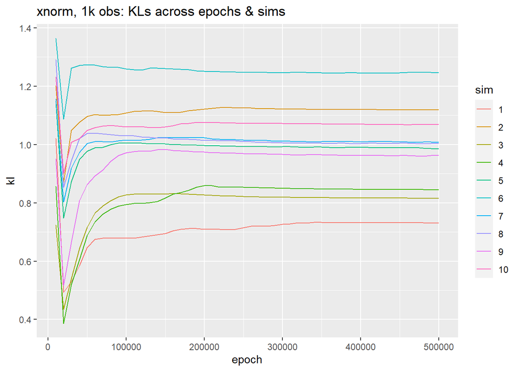

```r
lmat %>%
  as_data_frame() %>%
  mutate(sim = factor(sim)) %>%
  ggplot(aes(y = kl, x = epoch, color = sim)) +
  geom_line() +
  labs(title = "xnorm, 1k obs: KLs across epochs & sims")
```

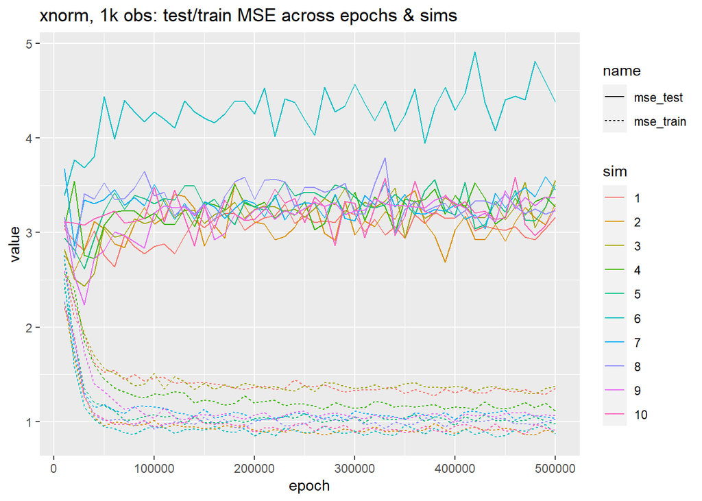

```r
lmat %>%
  as_data_frame() %>%
  mutate(sim = factor(sim)) %>%
  pivot_longer(cols = -c("epoch", "sim")) %>%
  filter(name != "kl") %>%
  ggplot(aes(x = epoch, color = sim, linetype = name)) +
  geom_line(aes(y = value)) +
  labs(title = "xnorm, 1k obs: test/train MSE across epochs & sims")
```